# Red Wine Analysis by Michael Christensen

# Univariate Plots Section

```
## [1] "Dataset Variables"
```

```
##  [1] "fixed.acidity"        "volatile.acidity"     "citric.acid"
##  [4] "residual.sugar"       "chlorides"            "free.sulfur.dioxide"
##  [7] "total.sulfur.dioxide" "density"              "pH"
## [10] "sulphates"            "alcohol"              "quality"
## [13] "rating"
```

```
## [1] "Dataset structure"
```

```
## 'data.frame':    1599 obs. of  13 variables:
##  $ fixed.acidity       : num  7.4 7.8 7.8 11.2 7.4 7.4 7.9 7.3 7.8 7.5 ...
##  $ volatile.acidity    : num  0.7 0.88 0.76 0.28 0.7 0.66 0.6 0.65 0.58 0.5 ...
##  $ citric.acid         : num  0 0 0.04 0.56 0 0 0.06 0 0.02 0.36 ...
##  $ residual.sugar      : num  1.9 2.6 2.3 1.9 1.9 1.8 1.6 1.2 2 6.1 ...
##  $ chlorides           : num  0.076 0.098 0.092 0.075 0.076 0.075 0.069 0.065 0.073 0.071 ...
##  $ free.sulfur.dioxide : num  11 25 15 17 11 13 15 15 9 17 ...
##  $ total.sulfur.dioxide: num  34 67 54 60 34 40 59 21 18 102 ...
##  $ density             : num  0.998 0.997 0.997 0.998 0.998 ...
##  $ pH                  : num  3.51 3.2 3.26 3.16 3.51 3.51 3.3 3.39 3.36 3.35 ...
##  $ sulphates           : num  0.56 0.68 0.65 0.58 0.56 0.56 0.46 0.47 0.57 0.8 ...
##  $ alcohol             : num  9.4 9.8 9.8 9.8 9.4 9.4 9.4 10 9.5 10.5 ...
##  $ quality             : Ord.factor w/ 6 levels "3"<"4"<"5"<"6"<..: 3 3 3 4 3 3 3 5 5 3 ...
##  $ rating              : Ord.factor w/ 3 levels "bad"<"average"<..: 2 2 2 2 2 2 2 3 3 2 ...
```

```
## [1] "Dataset Summary"
```

```
##  fixed.acidity   volatile.acidity  citric.acid    residual.sugar
##  Min.   : 4.60   Min.   :0.1200   Min.   :0.000   Min.   : 0.900
##  1st Qu.: 7.10   1st Qu.:0.3900   1st Qu.:0.090   1st Qu.: 1.900
##  Median : 7.90   Median :0.5200   Median :0.260   Median : 2.200
##  Mean   : 8.32   Mean   :0.5278   Mean   :0.271   Mean   : 2.539
##  3rd Qu.: 9.20   3rd Qu.:0.6400   3rd Qu.:0.420   3rd Qu.: 2.600
##  Max.   :15.90   Max.   :1.5800   Max.   :1.000   Max.   :15.500
##    chlorides       free.sulfur.dioxide total.sulfur.dioxide
##  Min.   :0.01200   Min.   : 1.00       Min.   :  6.00
##  1st Qu.:0.07000   1st Qu.: 7.00       1st Qu.: 22.00
##  Median :0.07900   Median :14.00       Median : 38.00
##  Mean   :0.08747   Mean   :15.87       Mean   : 46.47
##  3rd Qu.:0.09000   3rd Qu.:21.00       3rd Qu.: 62.00
##  Max.   :0.61100   Max.   :72.00       Max.   :289.00
##     density             pH          sulphates         alcohol      quality
##  Min.   :0.9901   Min.   :2.740   Min.   :0.3300   Min.   : 8.40   3: 10
##  1st Qu.:0.9956   1st Qu.:3.210   1st Qu.:0.5500   1st Qu.: 9.50   4: 53
##  Median :0.9968   Median :3.310   Median :0.6200   Median :10.20   5:681
##  Mean   :0.9967   Mean   :3.311   Mean   :0.6581   Mean   :10.42   6:638
##  3rd Qu.:0.9978   3rd Qu.:3.400   3rd Qu.:0.7300   3rd Qu.:11.10   7:199
##  Max.   :1.0037   Max.   :4.010   Max.   :2.0000   Max.   :14.90   8: 18
##      rating
##  bad    :  63
##  average:1319
##  good   : 217
##
##
##
```

```
## [1] "Explore Each Variable To Better Understand The Data"
```

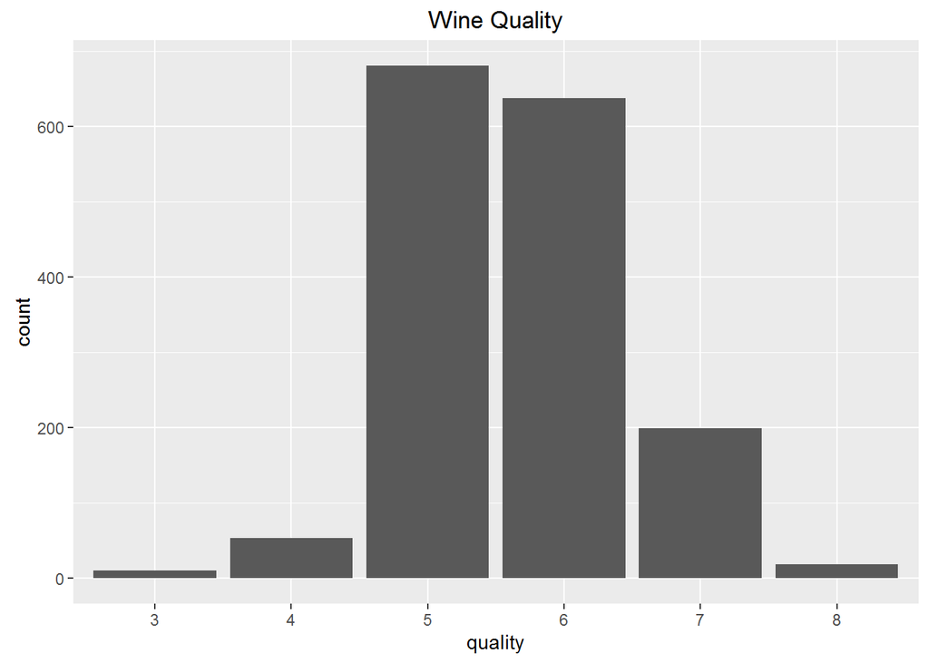

```
## [1] "Wine Count By Quality Category"
```

```
##
##   3   4   5   6   7   8
##  10  53 681 638 199  18
```

```
## The majority of the wines can be found in the 5 to 7 quality range.
```

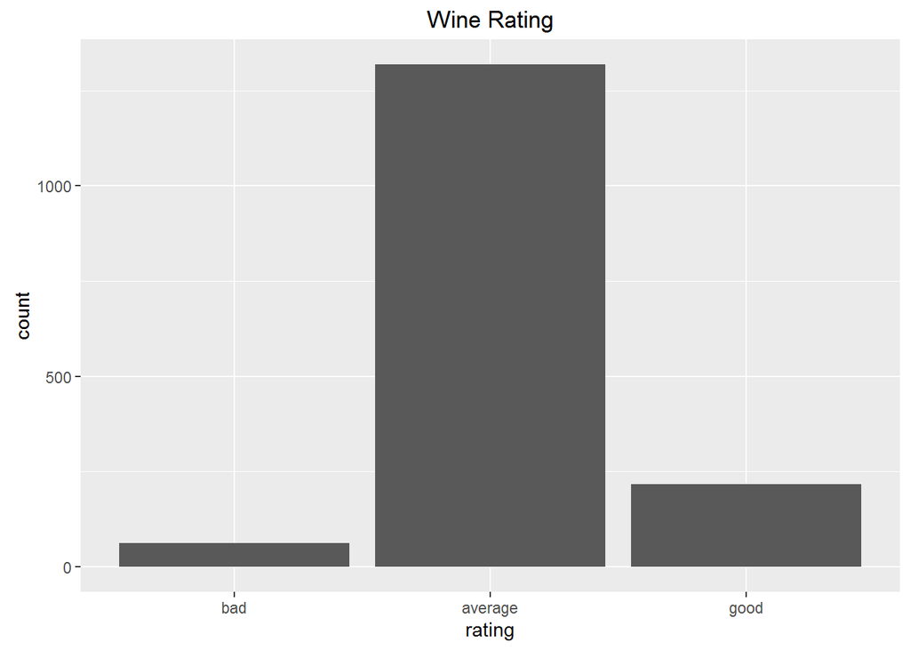

```
## [1] "Wine Count By Rating Category"
```

```
##
##     bad average    good
##      63    1319     217
```

```
## Most wines fall in to the average category (better than or equal to 5 and less than 7).
```

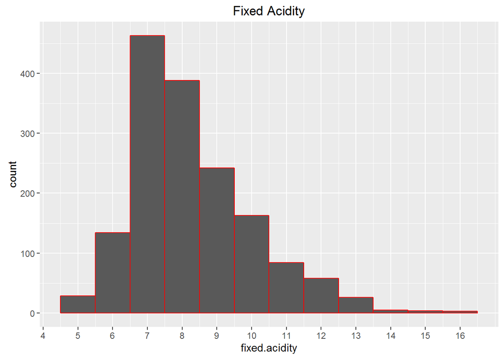

```
##    Min. 1st Qu.  Median    Mean 3rd Qu.    Max.
##    4.60    7.10    7.90    8.32    9.20   15.90
```

```
## A large number of wines have a fixed acidity close to the median (7.9 g / dm^3). Outliers are responsible for a higher mean than median.
```

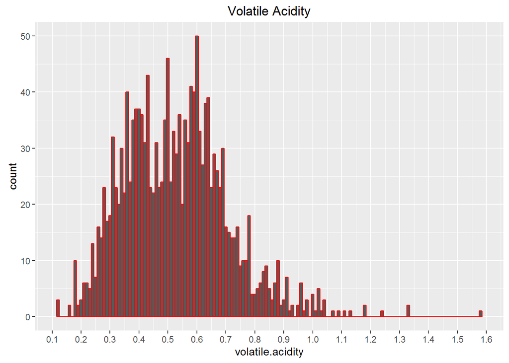

```
##    Min. 1st Qu.  Median    Mean 3rd Qu.    Max.
##  0.1200  0.3900  0.5200  0.5278  0.6400  1.5800
```

```
## A bimodal distribution is apparent with peaks at 0.4 and 0.6 g/dm^3. Outliers are also present in this dataset.
```

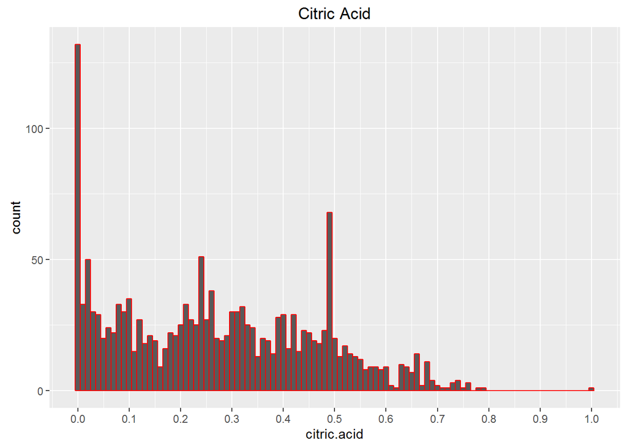

```
## [1] "Number of Samples with citric.acidity=0"
```

```
##       x freq
## 1 FALSE 1467
## 2  TRUE  132
```

```
##    Min. 1st Qu.  Median    Mean 3rd Qu.    Max.
##   0.000   0.090   0.260   0.271   0.420   1.000
```

[output not shown]

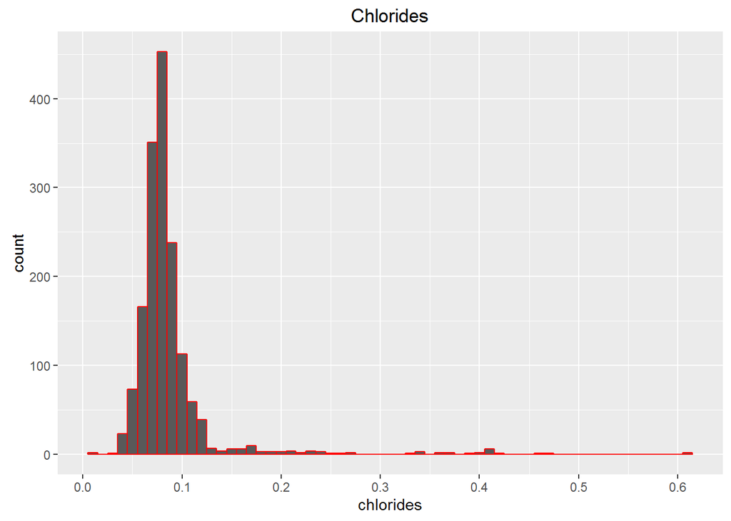

```
##    Min. 1st Qu.  Median    Mean 3rd Qu.    Max.
## 0.01200 0.07000 0.07900 0.08747 0.09000 0.61100
```

```
## There are a high concentration of wines around 0.079 g/dm^3 (the median). Some outliers are present in the higher ranges.
```

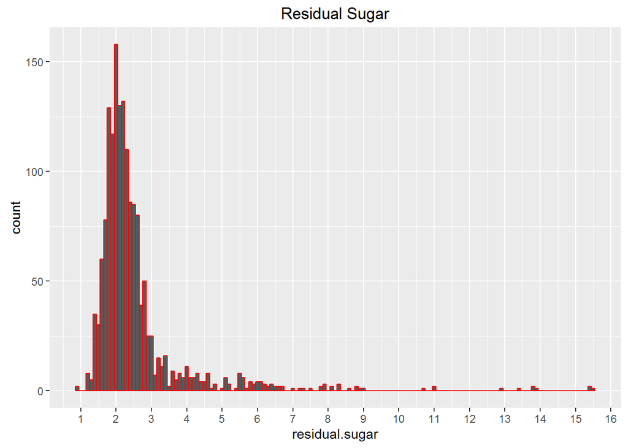

```
##    Min. 1st Qu.  Median    Mean 3rd Qu.    Max.
##   0.900   1.900   2.200   2.539   2.600  15.500
```

```
## There are a high concentration of wines around 2.2 g/dm^3 (the median). Some outliers are present in the higher ranges.
```

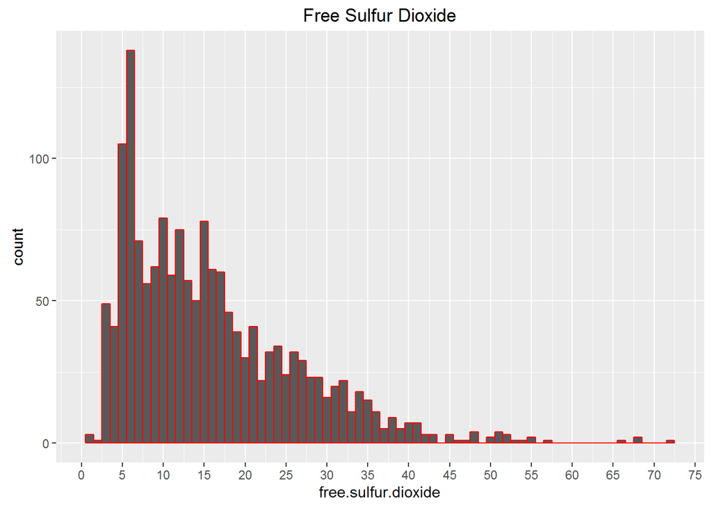

```
##    Min. 1st Qu.  Median    Mean 3rd Qu.    Max.
##    1.00    7.00   14.00   15.87   21.00   72.00
```

```
## There is a peak at 6 mg/dm^3. The distribution has a long right tail.
```

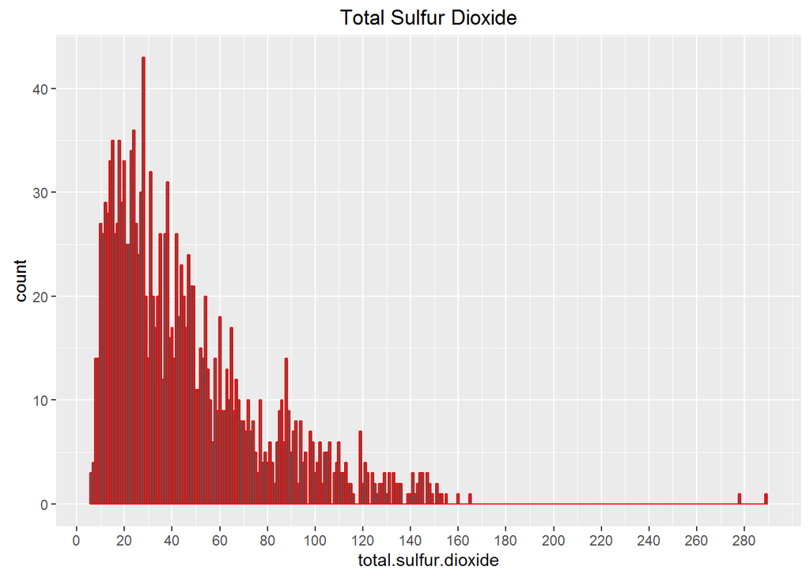

```
##    Min. 1st Qu.  Median    Mean 3rd Qu.    Max.
##    6.00   22.00   38.00   46.47   62.00  289.00
```

```
## This distribution has a long right tail. Some outliers are also apparent.
```

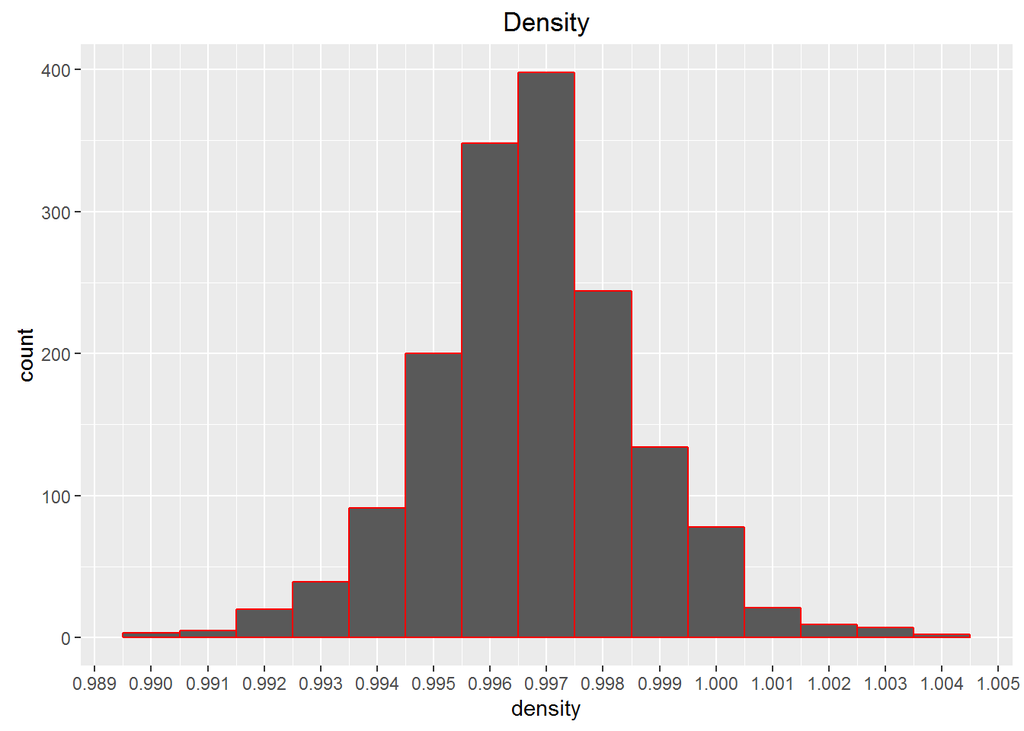

```
##    Min. 1st Qu.  Median    Mean 3rd Qu.    Max.
##  0.9901  0.9956  0.9968  0.9967  0.9978  1.0040
```

```
## [1] "This distribution looks roughly normal."
```

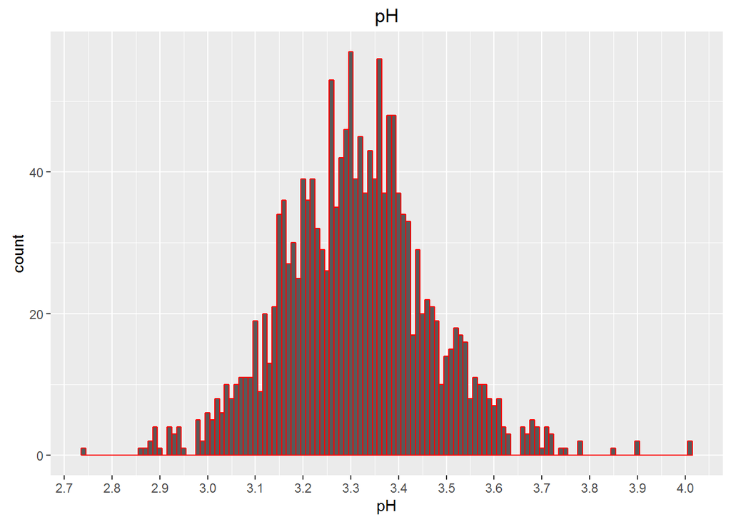

```
##    Min. 1st Qu.  Median    Mean 3rd Qu.    Max.
##   2.740   3.210   3.310   3.311   3.400   4.010
```

```
## This distribution looks roughly normal. However, there are some outliers on both the high and low ends.
```

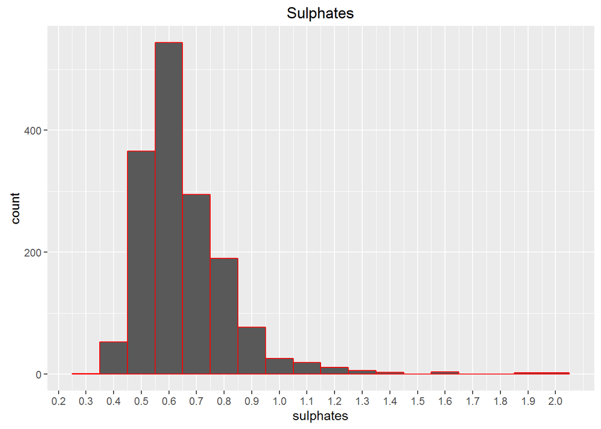

```
##    Min. 1st Qu.  Median    Mean 3rd Qu.    Max.
##  0.3300  0.5500  0.6200  0.6581  0.7300  2.0000
```

```
## A large number of samples fall close to the median (0.62 g/dm3). The shape of the distribution is comparable to that for residual.sugar and chlorides.
```

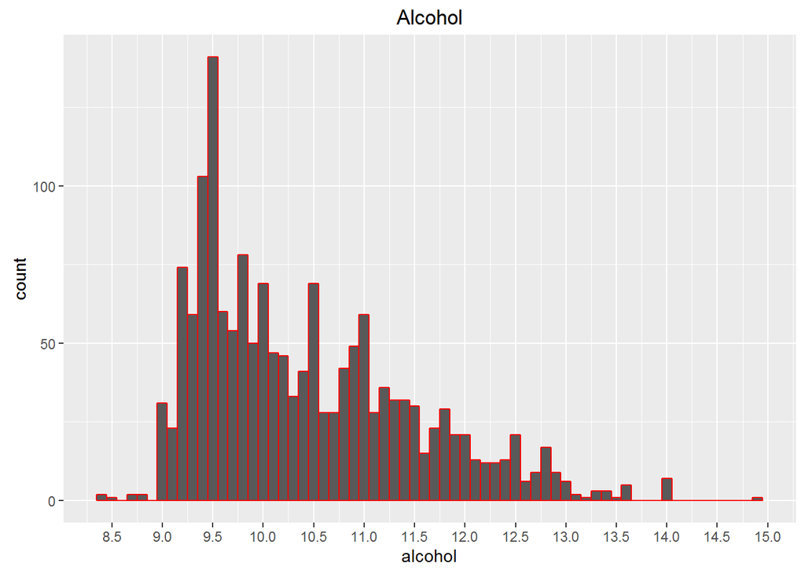

```
##    Min. 1st Qu.  Median    Mean 3rd Qu.    Max.
##    8.40    9.50   10.20   10.42   11.10   14.90
```

```
## The distribution is long-tailed and has a peak around 9.5.
```

# Univariate Analysis

### What is the structure of your dataset?

This red wine dataset has 12 features (I added a 13th: rating). There are 1599 observations. I transformed the quality feature from an integer type to an ordered factor (categorical variable).The rating is also an ordered factor. The other features are numerical type.

Variable Names– fixed.acidity, volatile.acidity, citric.acid, residual.sugar, chlorides, free.sulfur.dioxide, total.sulfur.dioxide, density, pH, sulphates, alcohol quality, rating

(worst) ——> (best) rating: bad, average, good quality: 3, 4, 5, 6, 7, 8

Other Observations: The median wine quality is 6. There are far more wine samples of average quality than bad or good. In fact, 82.4% of wine samples fall into the average category. Thissampling distribution may make predictive modeling difficult. It is also interesting to note that many variables in this dataset have non-normal distributions with longer right-hand tails.

### What is/are the main feature(s) of interest in your dataset?

The main feature of interest is quality. Quality and rating are inextricably linked by definition in this project. My goal is to understand what variablesare most closely tied to/influence wine quality.

### What other features in the dataset do you think will help support your investigation into your feature(s) of interest?

Based on the description of the attributes, I suspect that acidity (fixed and volatile), citric acid, residual sugar, chlorides, free sulphur dioxide, pH, and sulphates will provide a good starting point for investigating what most affects the quality of wine. As a non-wine drinker, however, I understand that exploring the relationships between all the variables will be necessary to give me a baseline for further analysis.

### Did you create any new variables from existing variables in the dataset?

Following the lead of some others, I created the categorial variable: rating. This grouping idea should help improve data visualizations later in the project.

### Of the features you investigated, were there any unusual distributions? Did you perform any operations on the data to tidy, adjust, or change the form of the data? If so, why did you do this?

The most unusual distributions were that of citric acid and volatile acidity. I did not perform any operation to alter these data. I removed X from the original dataset X since it was only the observation identifier and not useful in this analysis. I adjusted the quality variable to be an ordered factor to help with grouping and visualizations later in the project. At this point, I have not removed outliers or trimmed the data in any way.

# Bivariate Plots Section

## Correlation Between Variables

```
## [1] "Correlation Between Variables"
```

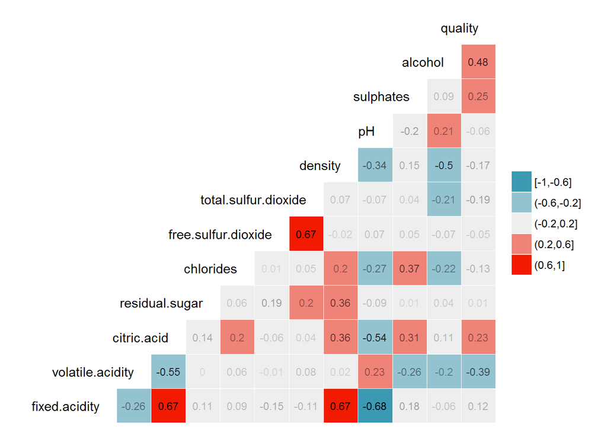

```
## The correlation diagram helps to quickly visualize the strength of the correlation between variables.
```

```
##
## ---------------------------------------------------------------------------
##           &nbsp;            fixed.acidity   volatile.acidity   citric.acid
## -------------------------- --------------- ------------------ -------------
##     **fixed.acidity**             1             -0.2561        **0.6717**
##
##    **volatile.acidity**        -0.2561             1           **-0.5525**
##
##      **citric.acid**         **0.6717**       **-0.5525**           1
##
##     **residual.sugar**         0.1148           0.001918         0.1436
##
##       **chlorides**            0.09371           0.0613          0.2038
##
##  **free.sulfur.dioxide**       -0.1538          -0.0105         -0.06098
##
##  **total.sulfur.dioxide**      -0.1132          0.07647          0.03553
##
##        **density**            **0.668**         0.02203        **0.3649**
##
##           **pH**             **-0.683**          0.2349        **-0.5419**
##
##       **sulphates**             0.183            -0.261        **0.3128**
##
##        **alcohol**            -0.06167          -0.2023          0.1099
##
##        **quality**             0.1241         **-0.3906**        0.2264
## ---------------------------------------------------------------------------
##
## Table: Table continues below
##
##
## -----------------------------------------------------------------------------
##           &nbsp;            residual.sugar   chlorides   free.sulfur.dioxide
## -------------------------- ---------------- ----------- ---------------------
##     **fixed.acidity**           0.1148        0.09371          -0.1538
##
##    **volatile.acidity**        0.001918       0.0613           -0.0105
##
##      **citric.acid**            0.1436        0.2038          -0.06098
```

[output cut: 66 more lines]

```
##
##  **free.sulfur.dioxide**     0.05166    -0.06941    -0.05066
##
##  **total.sulfur.dioxide**    0.04295     -0.2057     -0.1851
##
##        **density**           0.1485    **-0.4962**   -0.1749
##
##           **pH**             -0.1966     0.2056     -0.05773
##
##       **sulphates**             1        0.09359     0.2514
##
##        **alcohol**           0.09359        1      **0.4762**
##
##        **quality**           0.2514    **0.4762**       1
## --------------------------------------------------------------
```

```
## Most highly correlated variables with quality--> Alcohol (r=.48), Volatile Acidity (r=-.39), Sulphates (r=.25), Citric Acid (r=.23). I was surprised that most variables were only weakly correlated with quality.
```

```
## Density, chlorides, and pH have a weak negative correlation with quality. Pearson's r values are -.17, -.13, and -.06, respectively
```

[output not shown]

## Quality vs Alcohol

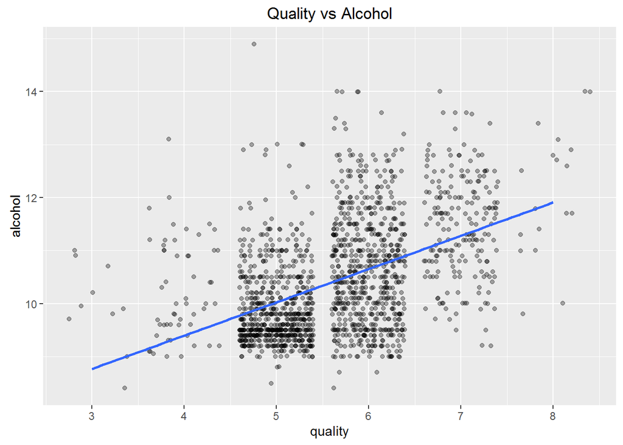

[output not shown]

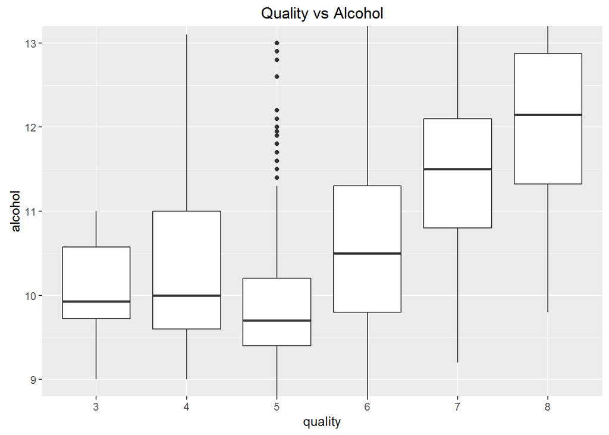

```
## [1] "Summary Statistics"
```

```
## quality: 3
##    Min. 1st Qu.  Median    Mean 3rd Qu.    Max.
##   8.400   9.725   9.925   9.955  10.580  11.000
## --------------------------------------------------------
## quality: 4
##    Min. 1st Qu.  Median    Mean 3rd Qu.    Max.
##    9.00    9.60   10.00   10.27   11.00   13.10
## --------------------------------------------------------
## quality: 5
##    Min. 1st Qu.  Median    Mean 3rd Qu.    Max.
##     8.5     9.4     9.7     9.9    10.2    14.9
## --------------------------------------------------------
## quality: 6
##    Min. 1st Qu.  Median    Mean 3rd Qu.    Max.
##    8.40    9.80   10.50   10.63   11.30   14.00
## --------------------------------------------------------
## quality: 7
##    Min. 1st Qu.  Median    Mean 3rd Qu.    Max.
##    9.20   10.80   11.50   11.47   12.10   14.00
## --------------------------------------------------------
## quality: 8
##    Min. 1st Qu.  Median    Mean 3rd Qu.    Max.
##    9.80   11.32   12.15   12.09   12.88   14.00
```

[output not shown]

## Quality vs Volatile Acidity

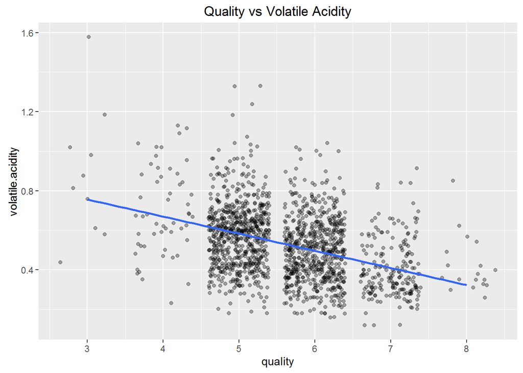

[output not shown]

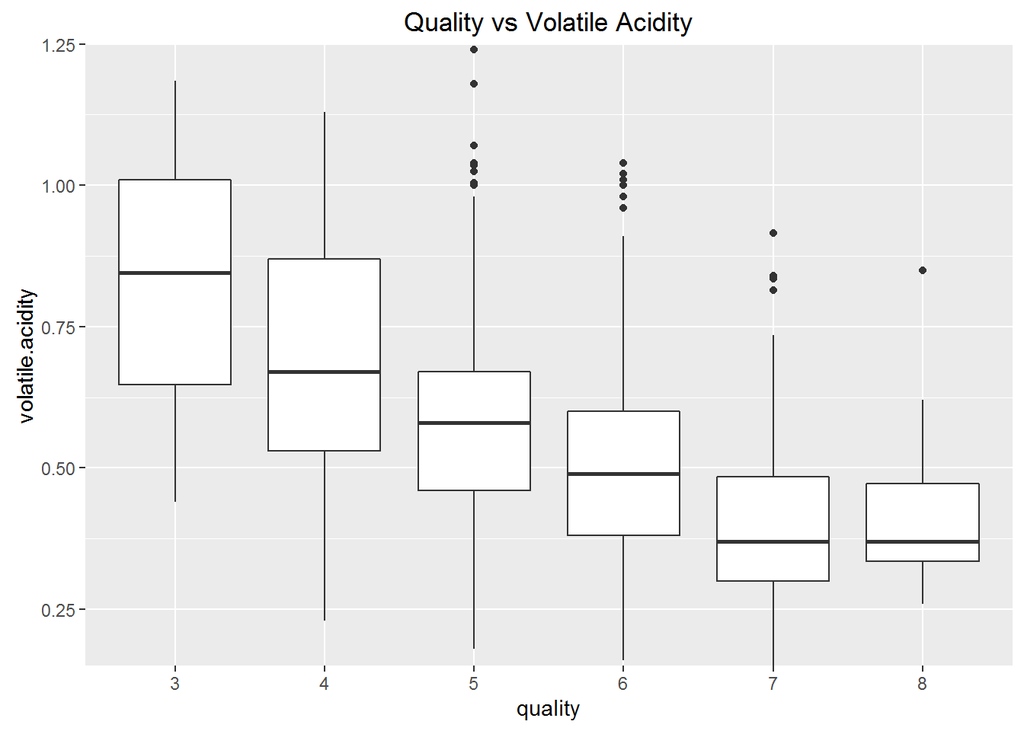

```
## [1] "Summary Statistics"
```

```
## quality: 3
##    Min. 1st Qu.  Median    Mean 3rd Qu.    Max.
##  0.4400  0.6475  0.8450  0.8845  1.0100  1.5800
## --------------------------------------------------------
## quality: 4
##    Min. 1st Qu.  Median    Mean 3rd Qu.    Max.
##   0.230   0.530   0.670   0.694   0.870   1.130
## --------------------------------------------------------
## quality: 5
##    Min. 1st Qu.  Median    Mean 3rd Qu.    Max.
##   0.180   0.460   0.580   0.577   0.670   1.330
## --------------------------------------------------------
## quality: 6
##    Min. 1st Qu.  Median    Mean 3rd Qu.    Max.
##  0.1600  0.3800  0.4900  0.4975  0.6000  1.0400
## --------------------------------------------------------
## quality: 7
##    Min. 1st Qu.  Median    Mean 3rd Qu.    Max.
##  0.1200  0.3000  0.3700  0.4039  0.4850  0.9150
## --------------------------------------------------------
## quality: 8
##    Min. 1st Qu.  Median    Mean 3rd Qu.    Max.
##  0.2600  0.3350  0.3700  0.4233  0.4725  0.8500
```

```
## The relationship between quality and volatile acidity is illustrated with boxplots. The y-limits have been modified to make the graphic easier to read. From the boxplots it is easy to see that in general lower quality wines have higher median volatile acidity.
```

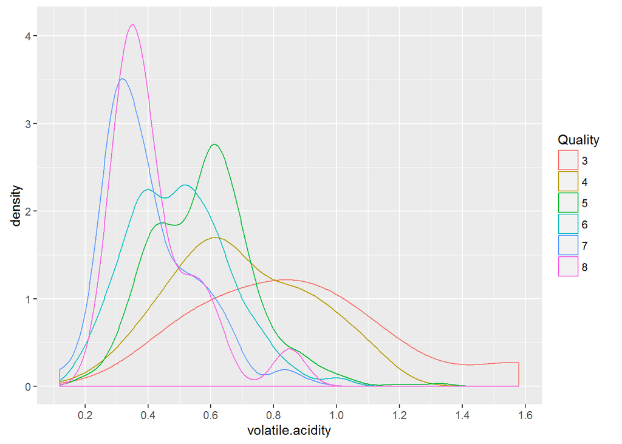

[output not shown]

## Quality vs Sulphates

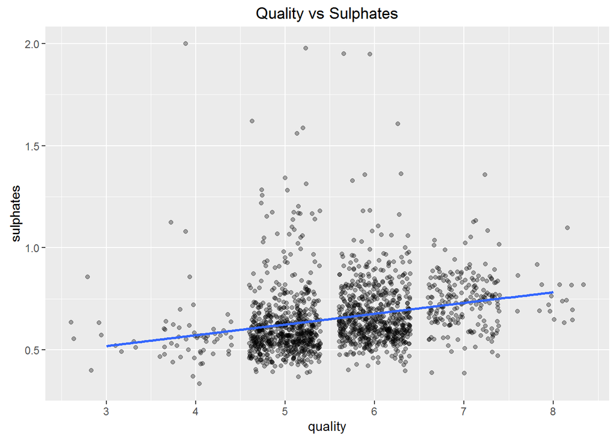

[output not shown]

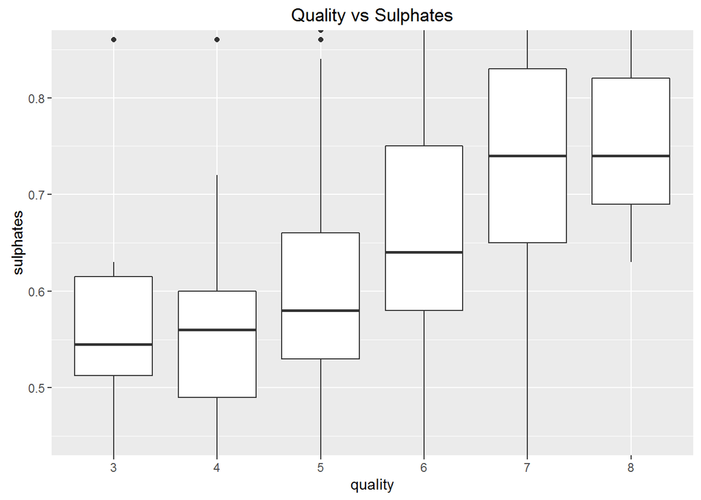

```
## [1] "Summary Statistics"
```

```
## quality: 3
##    Min. 1st Qu.  Median    Mean 3rd Qu.    Max.
##  0.4000  0.5125  0.5450  0.5700  0.6150  0.8600
## --------------------------------------------------------
## quality: 4
##    Min. 1st Qu.  Median    Mean 3rd Qu.    Max.
##  0.3300  0.4900  0.5600  0.5964  0.6000  2.0000
## --------------------------------------------------------
## quality: 5
##    Min. 1st Qu.  Median    Mean 3rd Qu.    Max.
##   0.370   0.530   0.580   0.621   0.660   1.980
## --------------------------------------------------------
## quality: 6
##    Min. 1st Qu.  Median    Mean 3rd Qu.    Max.
##  0.4000  0.5800  0.6400  0.6753  0.7500  1.9500
## --------------------------------------------------------
## quality: 7
##    Min. 1st Qu.  Median    Mean 3rd Qu.    Max.
##  0.3900  0.6500  0.7400  0.7413  0.8300  1.3600
## --------------------------------------------------------
## quality: 8
##    Min. 1st Qu.  Median    Mean 3rd Qu.    Max.
##  0.6300  0.6900  0.7400  0.7678  0.8200  1.1000
```

[output not shown]

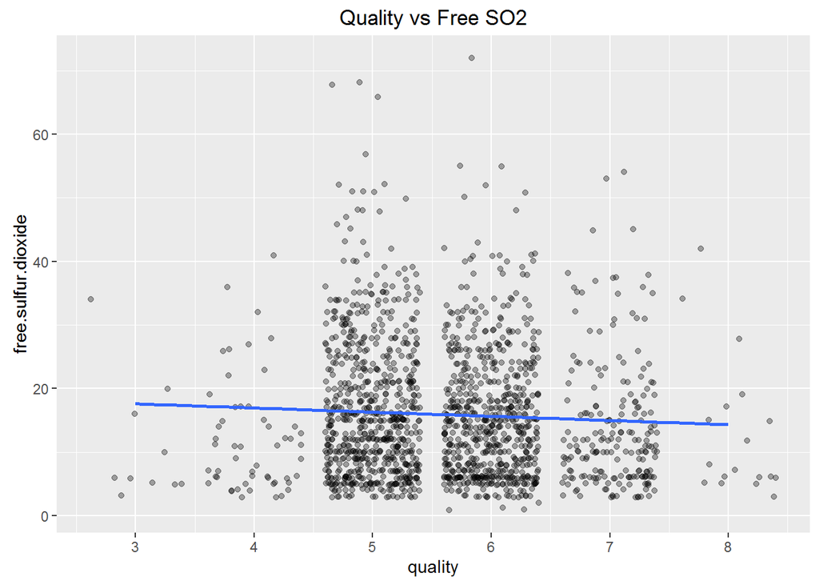

```
## A correlation close to 0 exists between quality and free SO2 (r=-.05, df=1597, p<.05, 95% CI: [-0.099430290 -0.001638987]). A linear regression line is overlaid in blue. Points are jittered to minimize overplotting.
```

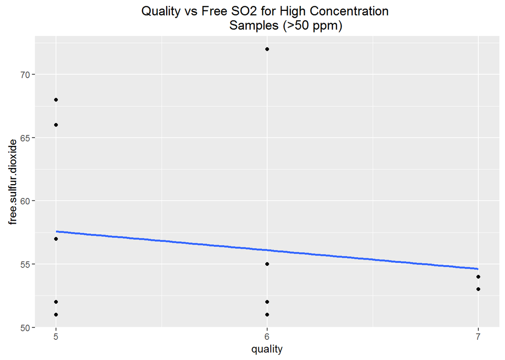

[output not shown]

## Quality vs Citric Acid

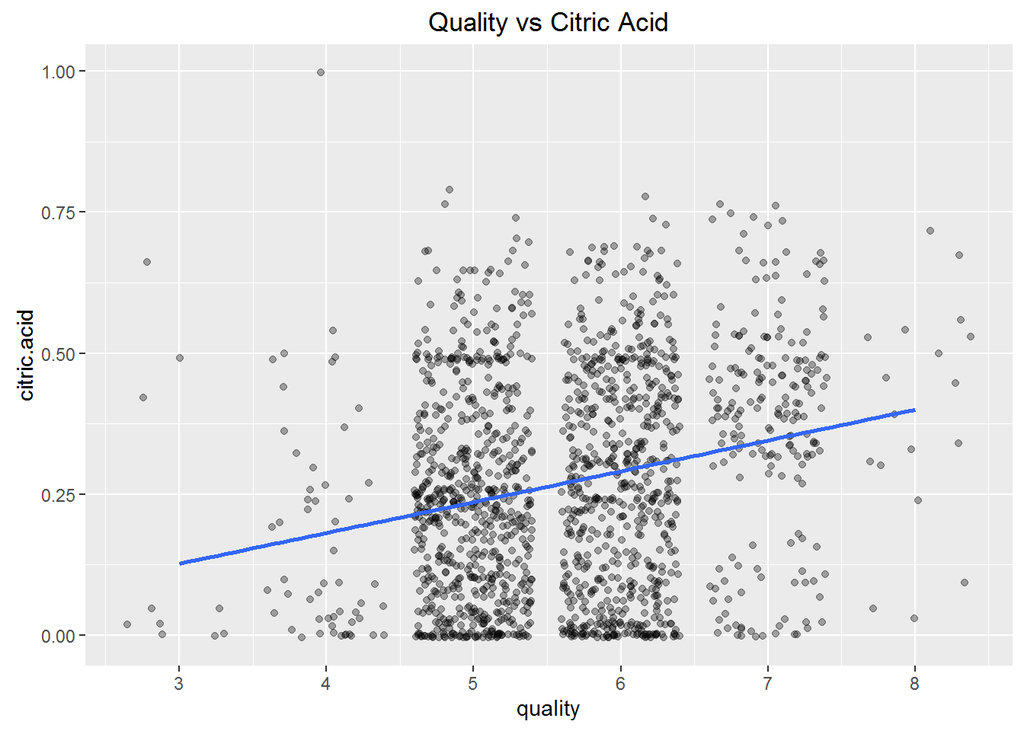

[output not shown]

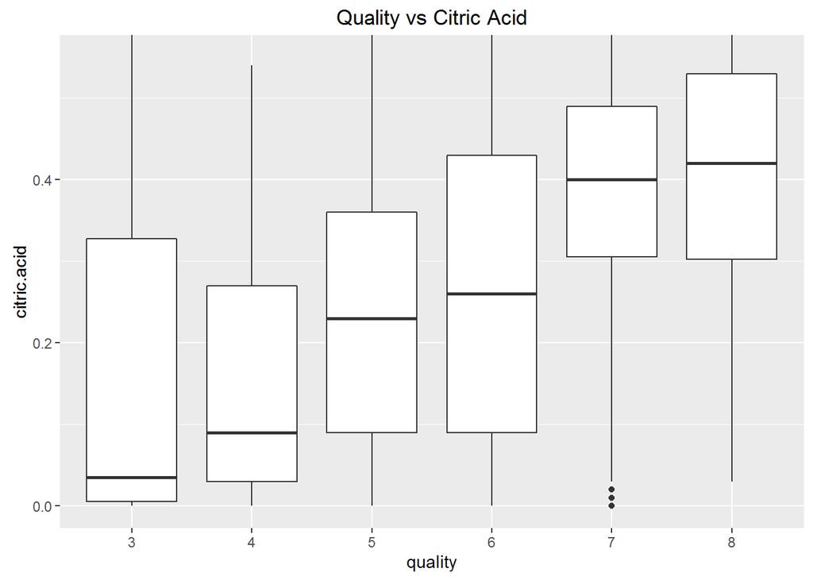

```
## [1] "Summary Statistics"
```

[output not shown]

[output not shown]

## Quality vs Residual Sugar

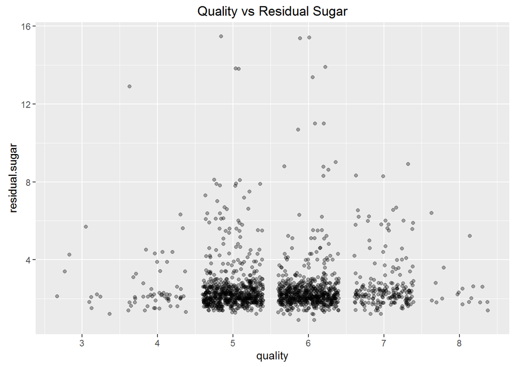

[output not shown]

## Density and Fixed Acidity

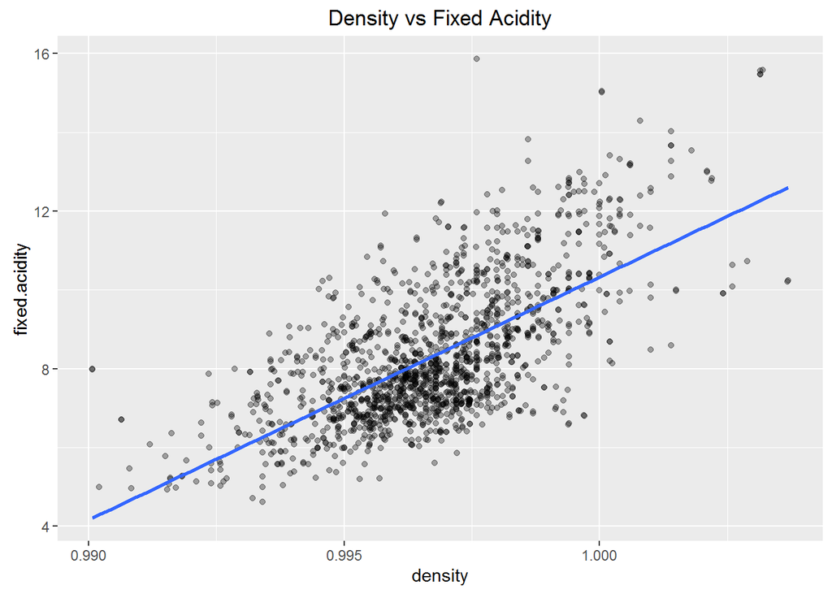

[output not shown]

## Fixed Acidity and pH

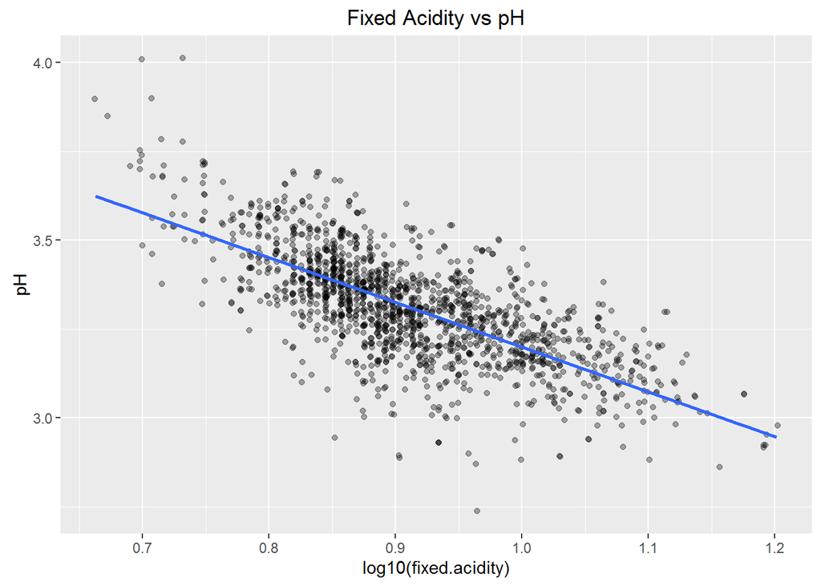

```
## Fixed acidity is negatively correlated with pH (r=-.68, df= 1597, p<.001, 95% CI: [-0.7082857 -0.6559174]). In the above graphic I transformed fixed acidity using log10 since ph=-log10[H+] I expected this relationship since higher acidity means a lower pH with all else held equal.
```

# Bivariate Analysis

### Talk about some of the relationships you observed in this part of the investigation. How did the feature(s) of interest vary with other features in the dataset?

For this project my primary goal is understanding how certain physiochemical variables influence the perceived quality of wine. Out of all the variables, alcohol (r=.48), volatile.acidity (r=-.39), sulphates (r=.25), and citric.acid (r=.23) had the highest correlation with quality. I focus on these below:

I presume that wines with a higher alcohol content had a “fuller” taste and hence were perceived as higher quality.

The negative correlation between volatile acidity and quality was not surprising since higher acetic acid levels (associated with higher volatile acidity) lead to a stronger vinegar taste.

The weak positive correlation between quality and sulphates was interesting. I wasn’t sure what to expect initially. On one hand, sulphates contribute to SO2 levels which act as an antimicrobial and antioxidant. I’m guessing this improves the taste of the wine. On the other hand, high free SO2 levels (>50 ppm) have a negative effect on the smell and taste of wine. This thought process led me to explore the relationship between free SO2 and quality for wine samples with greater than 50 ppm. I found no conclusive relationship, however, that indicacted the expected negative correlation. It is important to note that this was based on a small sample size (n=16).

The weak positive correlation between quality and citric acid was not totally unexpected. It is easy to imagine that a fresher tasting wine may be perceived as being of higher quality.

I was surprised to find that residual sugar concentrations and quality have a correlation close to 0. I figured that sweeter wines would be viewed as lower quality. Maybe there is some other chemistry at play here that I am not aware of.

### Did you observe any interesting relationships between the other features (not the main feature(s) of interest)?

The positive correlation between density and fixed acidity stood out to me. I later learned that the primary acids in wine all have densities greater than water so the higher the acid concentration in the sample the higher the density (with all else held constant).

The negative correlation between fixed acidity and pH wasn’t surprising. It is well-understood that as acidity increases pH decreases (with other variables held constant).

### What was the strongest relationship you found?

The strongest relationship that I found was between fixed acidity and pH.

# Multivariate Plots Section

## Explore the Relationship Between Alcohol, Volatile Acidity, and Quality

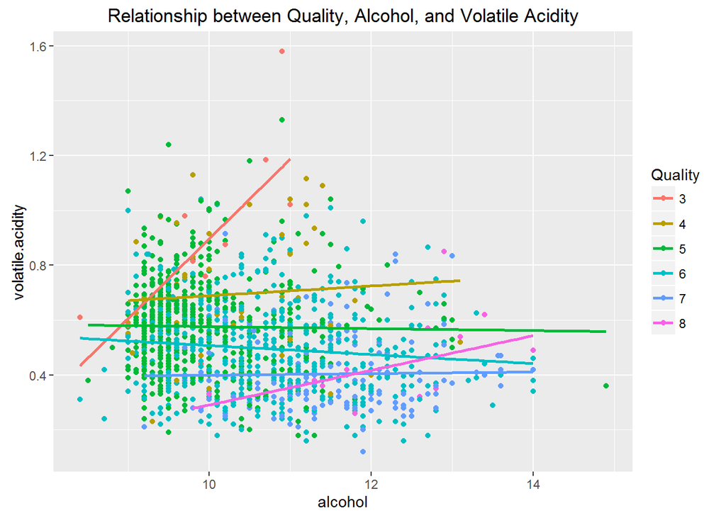

```
## [1] "Some clustering of similar quality wines is present."
```

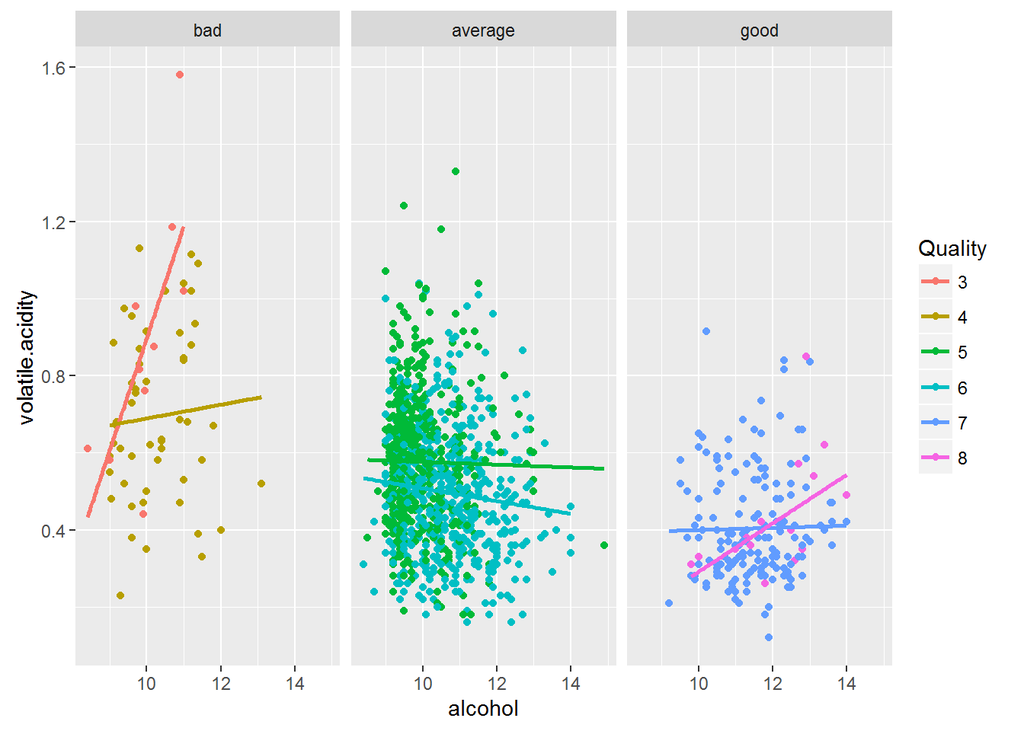

```
## [1] "Summary Stats: Alcohol"
```

```
## rating: bad
##    Min. 1st Qu.  Median    Mean 3rd Qu.    Max.
##    8.40    9.60   10.00   10.22   11.00   13.10
## --------------------------------------------------------
## rating: average
##    Min. 1st Qu.  Median    Mean 3rd Qu.    Max.
##    8.40    9.50   10.00   10.25   10.90   14.90
## --------------------------------------------------------
## rating: good
##    Min. 1st Qu.  Median    Mean 3rd Qu.    Max.
##    9.20   10.80   11.60   11.52   12.20   14.00
```

```
## [1] "Summary Stats: Volatile Acidity"
```

```
## rating: bad
##    Min. 1st Qu.  Median    Mean 3rd Qu.    Max.
##  0.2300  0.5650  0.6800  0.7242  0.8825  1.5800
## --------------------------------------------------------
## rating: average
##    Min. 1st Qu.  Median    Mean 3rd Qu.    Max.
##  0.1600  0.4100  0.5400  0.5386  0.6400  1.3300
## --------------------------------------------------------
## rating: good
##    Min. 1st Qu.  Median    Mean 3rd Qu.    Max.
##  0.1200  0.3000  0.3700  0.4055  0.4900  0.9150
```

```
## [1] "Volatile Acidity: Variance"
```

```
## rating: bad
## [1] 0.06148888
## --------------------------------------------------------
## rating: average
## [1] 0.02811625
## --------------------------------------------------------
## rating: good
## [1] 0.02101419
```

[output not shown]

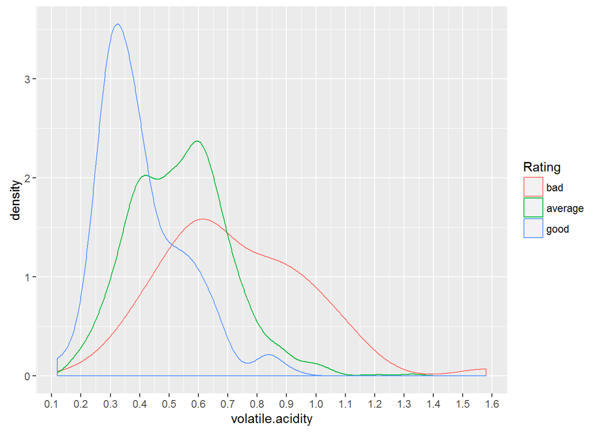

[output not shown]

## Explore the Relationship Between Alcohol, Sulphates, and Quality

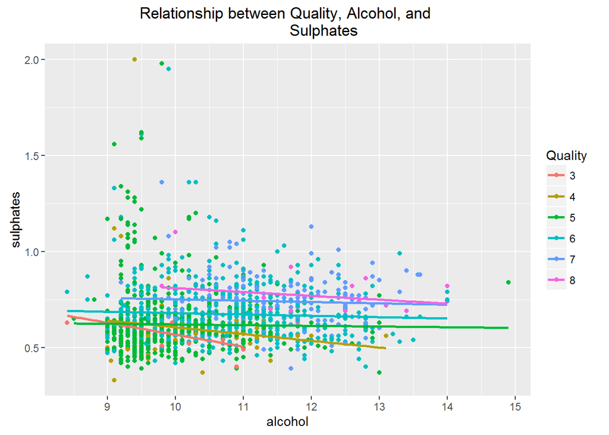

```
## It seems like there is some clustering of samples by wine quality. I need to break this graphic down further to explore this.
```

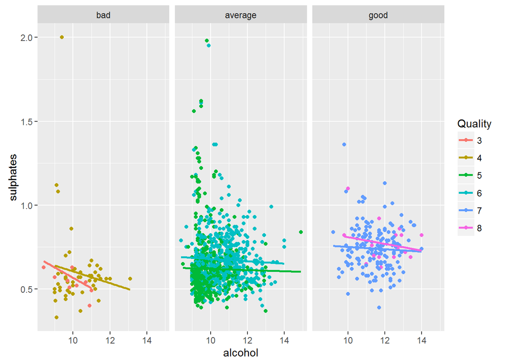

```
## [1] "Summary Stats: Sulphates"
```

```
## rating: bad
##    Min. 1st Qu.  Median    Mean 3rd Qu.    Max.
##  0.3300  0.4950  0.5600  0.5922  0.6000  2.0000
## --------------------------------------------------------
## rating: average
##    Min. 1st Qu.  Median    Mean 3rd Qu.    Max.
##  0.3700  0.5400  0.6100  0.6473  0.7000  1.9800
## --------------------------------------------------------
## rating: good
##    Min. 1st Qu.  Median    Mean 3rd Qu.    Max.
##  0.3900  0.6500  0.7400  0.7435  0.8200  1.3600
```

```
## [1] "Sulphates: Variance"
```

```
## rating: bad
## [1] 0.05032079
## --------------------------------------------------------
## rating: average
## [1] 0.02800062
## --------------------------------------------------------
## rating: good
## [1] 0.01796624
```

[output not shown]

## Explore the Relationship Between Alcohol, Citric Acid, and Quality

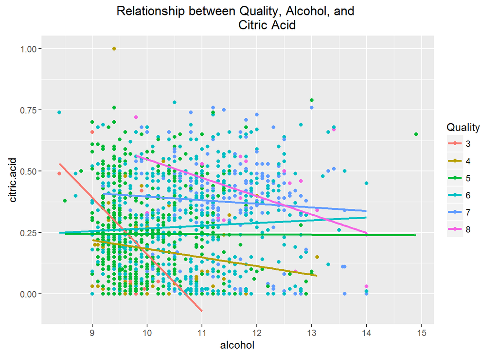

```
## It seems like for each quality category a wide range of citric acid concentrations exist. I saw this earlier with boxplots.
```

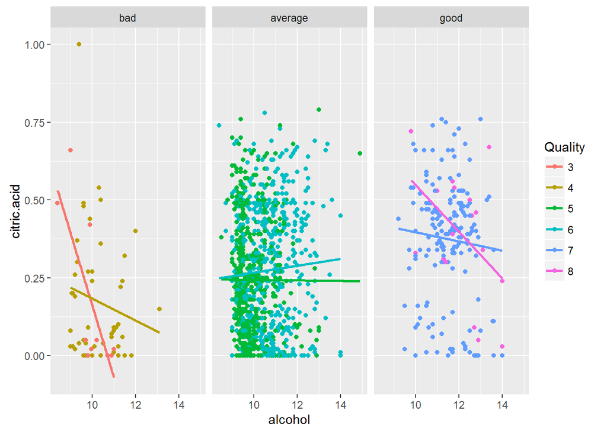

```
## [1] "Summary Stats: Citric Acid"
```

```
## factor(rating): bad
##    Min. 1st Qu.  Median    Mean 3rd Qu.    Max.
##  0.0000  0.0200  0.0800  0.1737  0.2700  1.0000
## --------------------------------------------------------
## factor(rating): average
##    Min. 1st Qu.  Median    Mean 3rd Qu.    Max.
##  0.0000  0.0900  0.2400  0.2583  0.4000  0.7900
## --------------------------------------------------------
## factor(rating): good
##    Min. 1st Qu.  Median    Mean 3rd Qu.    Max.
##  0.0000  0.3000  0.4000  0.3765  0.4900  0.7600
```

```
## [1] "Citric Acid: Variance"
```

```
## factor(rating): bad
## [1] 0.0430171
## --------------------------------------------------------
## factor(rating): average
## [1] 0.03534198
## --------------------------------------------------------
## factor(rating): good
## [1] 0.0378062
```

```
## The high degree of dispersion of data points in all ratings categories is apparent. The variances in citric acid concentrations are comparable between bad, average, and good wines. In general, the best rated wines have high alcohol content and high citric acid.
```

## Build a Model

```
##
## Calls:
## m1: lm(formula = I(quality) ~ I(alcohol), data = wine_numeric)
## m2: lm(formula = I(quality) ~ I(alcohol) + volatile.acidity, data = wine_numeric)
## m3: lm(formula = I(quality) ~ I(alcohol) + volatile.acidity + sulphates,
##     data = wine_numeric)
## m4: lm(formula = I(quality) ~ I(alcohol) + volatile.acidity + sulphates +
##     citric.acid, data = wine_numeric)
##
## ================================================================
##                        m1         m2         m3         m4
## ----------------------------------------------------------------
##   (Intercept)        1.875***   3.095***   2.611***   2.646***
##                     (0.175)    (0.184)    (0.196)    (0.201)
##   I(alcohol)         0.361***   0.314***   0.309***   0.309***
##                     (0.017)    (0.016)    (0.016)    (0.016)
##   volatile.acidity             -1.384***  -1.221***  -1.265***
##                                (0.095)    (0.097)    (0.113)
##   sulphates                                0.679***   0.696***
##                                           (0.101)    (0.103)
##   citric.acid                                        -0.079
##                                                      (0.104)
## ----------------------------------------------------------------
##   R-squared              0.2        0.3        0.3        0.3
##   adj. R-squared         0.2        0.3        0.3        0.3
##   sigma                  0.7        0.7        0.7        0.7
##   F                    468.3      370.4      268.9      201.8
##   p                      0.0        0.0        0.0        0.0
##   Log-likelihood     -1721.1    -1621.8    -1599.4    -1599.1
##   Deviance             805.9      711.8      692.1      691.9
##   AIC                 3448.1     3251.6     3208.8     3210.2
##   BIC                 3464.2     3273.1     3235.7     3242.4
##   N                   1599       1599       1599       1599
## ================================================================
```

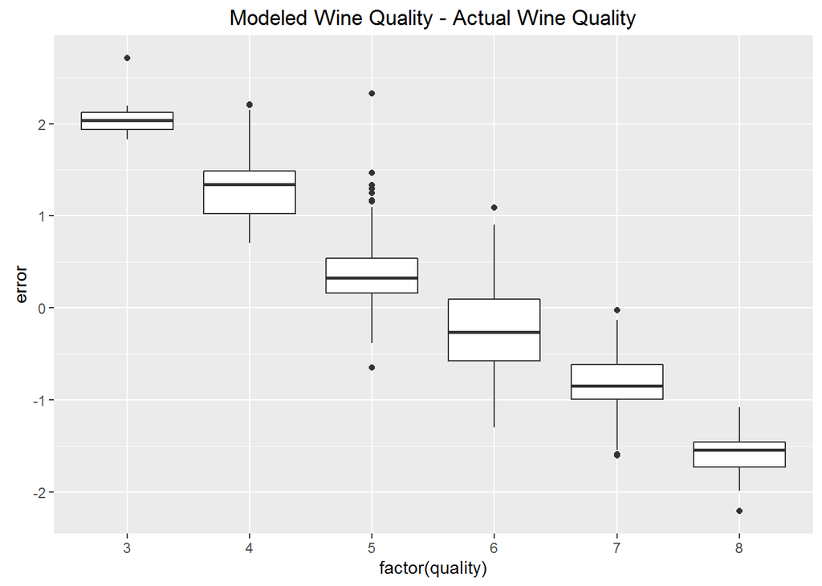

[output not shown]

# Multivariate Analysis

### Talk about some of the relationships you observed in this part of the investigation. Were there features that strengthened each other in terms of looking at your feature(s) of interest?

For this part of the analysis I explored the relationship between wine quality and the variables that had the highest correlation with it (alcohol, volatile acidity, and sulphates). Higher alcohol and lower volatile acidity wine samples were generally rated as higher quality. The same was true of wines with higher alcohol and higher sulphate concentrations. Wines with higher alcohol and higher citric acid were also percieved as higher quality. Breaking the individual scatter plots down by rating enabled me to visualize these multi-variable relationships with more ease.

### Were there any interesting or surprising interactions between features?

I was suprised that in general higher rated wines had higher sulphate concentrations. Understanding that suphates act as an antimicrobrial could help to explain this finding if the presence of microbrobes makes the wine taste less pleasant. It is clear from the multivariate analysis that the samples with the highest sulphate concentrations did not make the good rating category. These outlier samples fell in the bad and average categories. I presume this was the result of higher free sulphur dioxide concentrations which can negatively affect the smell and taste of wine. My exploration of this expectation in the bivariate analysis section, however, did not provide evidence of this.

### OPTIONAL: Did you create any models with your dataset? Discuss the strengths and limitations of your model.

# Final Plots and Summary

### Plot One (Quality Vs Alcohol)

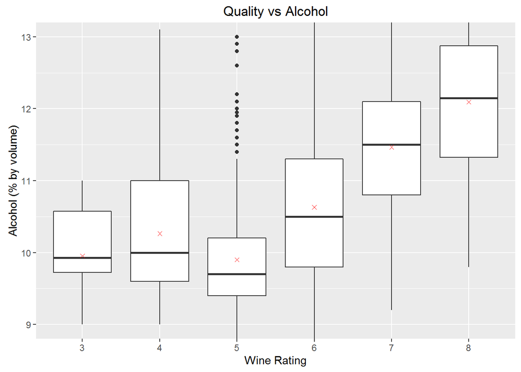

```
## [1] "Summary Statistics"
```

```
## quality: 3
##    Min. 1st Qu.  Median    Mean 3rd Qu.    Max.
##   8.400   9.725   9.925   9.955  10.580  11.000
## --------------------------------------------------------
## quality: 4
##    Min. 1st Qu.  Median    Mean 3rd Qu.    Max.
##    9.00    9.60   10.00   10.27   11.00   13.10
## --------------------------------------------------------
## quality: 5
##    Min. 1st Qu.  Median    Mean 3rd Qu.    Max.
##     8.5     9.4     9.7     9.9    10.2    14.9
## --------------------------------------------------------
## quality: 6
##    Min. 1st Qu.  Median    Mean 3rd Qu.    Max.
##    8.40    9.80   10.50   10.63   11.30   14.00
## --------------------------------------------------------
## quality: 7
##    Min. 1st Qu.  Median    Mean 3rd Qu.    Max.
##    9.20   10.80   11.50   11.47   12.10   14.00
## --------------------------------------------------------
## quality: 8
##    Min. 1st Qu.  Median    Mean 3rd Qu.    Max.
##    9.80   11.32   12.15   12.09   12.88   14.00
```

### Description One

These boxplots are broken down by wine quality. The y-limits have been modified to better display the bulk of the data. The mean value for alcohol percent by volume for each individual quality category is overlaid as a red x. Out of all the physicochemical variables in the dataset, alcohol had the strongest correlation with quality (r=.48, df=1597, p<.001, 95% CI: [0.4373540 0.5132081]). It seems that if a wine tastes stronger then the perceived quality is higher.

### Plot Two (Quality vs Alcohol and Volatile Acidity)

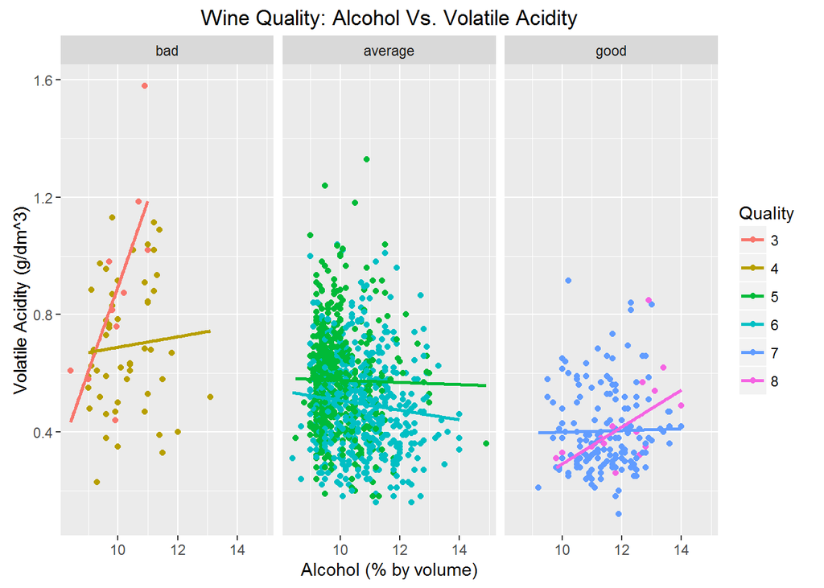

```
## [1] "Summary Stats: Volatile Acidity"
```

```
## quality: 3
##    Min. 1st Qu.  Median    Mean 3rd Qu.    Max.
##  0.4400  0.6475  0.8450  0.8845  1.0100  1.5800
## --------------------------------------------------------
## quality: 4
##    Min. 1st Qu.  Median    Mean 3rd Qu.    Max.
##   0.230   0.530   0.670   0.694   0.870   1.130
## --------------------------------------------------------
## quality: 5
##    Min. 1st Qu.  Median    Mean 3rd Qu.    Max.
##   0.180   0.460   0.580   0.577   0.670   1.330
## --------------------------------------------------------
## quality: 6
##    Min. 1st Qu.  Median    Mean 3rd Qu.    Max.
##  0.1600  0.3800  0.4900  0.4975  0.6000  1.0400
## --------------------------------------------------------
## quality: 7
##    Min. 1st Qu.  Median    Mean 3rd Qu.    Max.
##  0.1200  0.3000  0.3700  0.4039  0.4850  0.9150
## --------------------------------------------------------
## quality: 8
##    Min. 1st Qu.  Median    Mean 3rd Qu.    Max.
##  0.2600  0.3350  0.3700  0.4233  0.4725  0.8500
```

### Description Two

This scatter plot is broken down by rating. From the graphic it is easy to see that higher rated wines typically have higher alcohol content and lower volatile acidity. Wines with high volatile acidity have higher concentrations of acetic acid which can give the wine a vinegar taste. Regression lines are overlaid to illustrate the relationship between alcohol content and volatile acidity concentration by quality category.

### Plot Three (Quality Vs Alcohol and Sulphates)

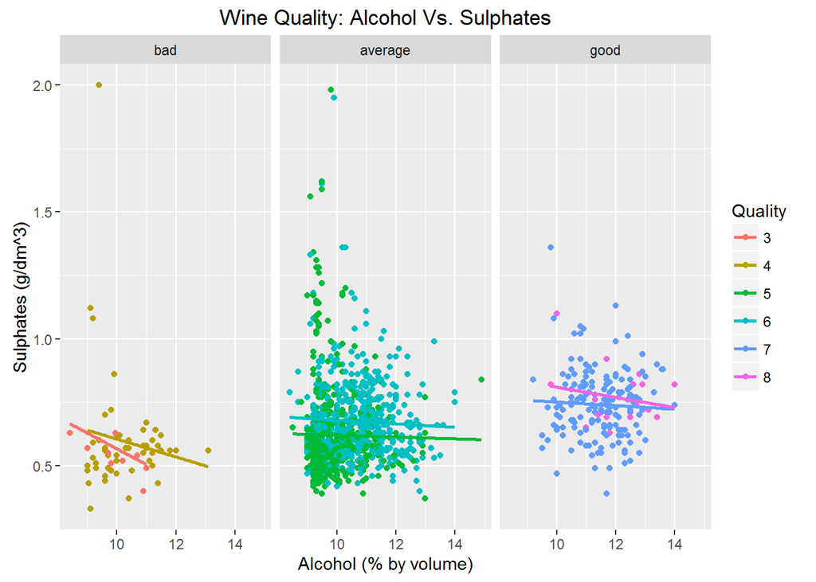

```
## [1] "Summary Stats: Sulphates"
```

```
## quality: 3
##    Min. 1st Qu.  Median    Mean 3rd Qu.    Max.
##  0.4000  0.5125  0.5450  0.5700  0.6150  0.8600
## --------------------------------------------------------
## quality: 4
##    Min. 1st Qu.  Median    Mean 3rd Qu.    Max.
##  0.3300  0.4900  0.5600  0.5964  0.6000  2.0000
## --------------------------------------------------------
## quality: 5
##    Min. 1st Qu.  Median    Mean 3rd Qu.    Max.
##   0.370   0.530   0.580   0.621   0.660   1.980
## --------------------------------------------------------
## quality: 6
##    Min. 1st Qu.  Median    Mean 3rd Qu.    Max.
##  0.4000  0.5800  0.6400  0.6753  0.7500  1.9500
## --------------------------------------------------------
## quality: 7
##    Min. 1st Qu.  Median    Mean 3rd Qu.    Max.
##  0.3900  0.6500  0.7400  0.7413  0.8300  1.3600
## --------------------------------------------------------
## quality: 8
##    Min. 1st Qu.  Median    Mean 3rd Qu.    Max.
##  0.6300  0.6900  0.7400  0.7678  0.8200  1.1000
```

```
## [1] "Variance: Sulphates"
```

```
## rating: bad
## [1] 0.05032079
## --------------------------------------------------------
## rating: average
## [1] 0.02800062
## --------------------------------------------------------
## rating: good
## [1] 0.01796624
```

# Reflection

The goal of this project was to work with a real-world dataset and get familiar with some exploratory data analysis techniques in R. The redwine dataset used here contains 1599 observations of 12 variables (after removing “X”). The data was tidy in that variables were provided in columns and each row represented an observation. Not much data wrangling was necessary.

To simplify some aspects of my code and to facilitate creating certain figures and summary tables throughout the project, I created a duplicate wine dataframe with variable quantities represented only in a numeric form. I called this dataframe “wine_numeric”. With the original wine dataframe (“wine”) I transformed the quality variable into an ordered factor. I also added an additional “rating” categorical variable to the dataframe to break down quality into bad, average, and good. This helped make complex, cluttered graphics easier to read later in the project. I realize that creating a duplicate dataframe is not best practice since it uses computer resources to store it in memory. I did struggle to some degree switching quickly back and forth between ordered factors and numerical values and having 2 separate dataframes helped to alleviate this issue.

My ultimate goal was to understand which physiochemical properties in the provided dataset had the biggest influence on the perceived quality of wine. I attacked the project head-on, exploring the relationship between all the variables simultaneously with a correlation diagram (corrgram). From this I was able to quickly and easily identify the variables most postitively or negatively correlated with quality. I found that alcohol, volatile acidity, and sulphate concentration had the highest absolute correlation value with quality and I subsequenly explored these variables and relationships thoroughly.

In future analysis of wine quality it would be nice to evaluate more input variables. I believe that defining the quality of wine in some quantitative way without a wine expert’s opinion would also make analysis more robust and less prone to personal preference bias.